# Homework 01

STAT 430, Fall 2017

Due: Friday, September 15, 11:59 PM

# Exercise 1

```r
library(tibble)
library(readr)

make_hw01_data = function(n_obs = 1000) {

  a = runif(n = n_obs, min = 0, max = 2)
  b = runif(n = n_obs, min = 0, max = 2)
  c = runif(n = n_obs, min = 0, max = 2)
  d = rbinom(n = n_obs, size = 1, p = 0.5)
  eps = rnorm(n = n_obs, mean = 0 , sd = 0.5)
  y = -5 + 3 * a ^ 2 + 4 * c + 3.5 * c * d + eps
  tibble(y, a, b, c, d)

}

set.seed(42)
hw01_data = make_hw01_data()
write_csv(hw01_data, "hw01-data.csv")
```

**[10 points]** This question will use data in a file called `hw01-data.csv`. The data contains four predictors: `a`, `b`, `c`, `d`, and a response `y`.

```r
hw01_data = read_csv("hw01-data.csv")
```

After reading in the data as `hw01_data`, use the following code to test-train split the data.

```r
set.seed(42)
train_index = sample(1:nrow(hw01_data), size = round(0.5 * nrow(hw01_data)))
train_data = hw01_data[train_index, ]
test_data = hw01_data[-train_index, ]
```

Next, fit four linear models using the training data:

- Model 1: `y ~ .`
- Model 2: `y ~ . + I(a ^ 2) + I(b ^ 2) + I(c ^ 2)`
- Model 3: `y ~ . ^ 2 + I(a ^ 2) + I(b ^ 2) + I(c ^ 2)`
- Model 4: `y ~ a * b * c * d + I(a ^ 2) + I(b ^ 2) + I(c ^ 2)`

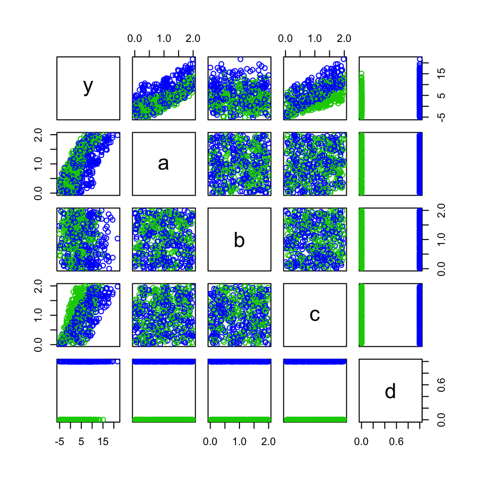

```r
pairs(train_data, col = train_data$d + 3)
```

Instead of `pairs()` which also shows the relationships among the predictors, we could instead use the `featurePlot()` function from the `caret` package.

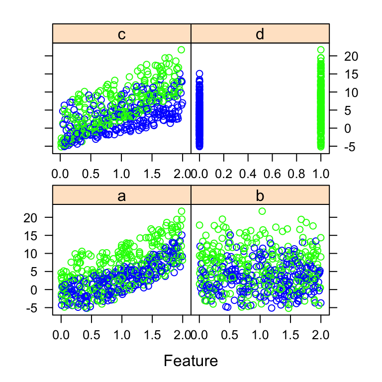

```r
library(caret)
featurePlot(x = train_data[, c("a", "b", "c", "d")], y = train_data$y,
            col = ifelse(train_data$d, "Green", "Blue"))
```

```r
fit1 = lm(y ~ ., data = train_data)
fit2 = lm(y ~ a + b + c + d + I(a ^ 2) + I(b ^ 2) + I(c ^ 2), data = train_data)
fit3 = lm(y ~ . ^ 2 + I(a ^ 2) + I(b ^ 2) + I(c ^ 2), data = train_data)
fit4 = lm(y ~ a * b * c * d + I(a ^ 2) + I(b ^ 2) + I(c ^ 2), data = train_data)
fit5 = lm(y ~ a + b + c * d + I(a ^ 2), data = train_data)
```

For each of the models above, report:

- Train RMSE
- Test RMSE
- Number of Parameters, Excluding the Variance

To receive full marks, arrange this information in a well formatted table. Also note which model is best for making predictions.

**Solution:**

```r
model_list = list(fit1, fit2, fit3, fit4, fit5)

train_rmse = sapply(model_list, get_rmse, data = train_data, response = "y")
test_rmse = sapply(model_list, get_rmse, data = test_data, response = "y")
num_params = sapply(model_list, get_num_params)
```

**Comments**: The results can be seen in the table below. Note that there is also a `fit5` which is used later. Be aware that the code to create the table below can be found in the accompanying `.Rmd` file, which also includes some helper functions written to aide in creating the numerical results.

| Model | Train RMSE | Test RMSE | Parameters |
| --- | --- | --- | --- |
| `fit1` | 1.4381782 | 1.4286911 | **5** |
| `fit2` | 1.1242482 | 1.1526319 | 8 |
| `fit3` | 0.5105619 | *0.5206716* | 14 |
| `fit4` | **0.5082713** | 0.5211251 | 19 |
| `fit5` | 0.5138062 | **0.5164304** | 7 |

Based on these results, **Model 3** is the best model for prediction. (`fit5` was not required. )

**[Not Graded]** For fun, find a model that outperforms each of the models above. *Hint:* Consider some exploratory data analysis. *Hint:* Your instructor’s solution uses a model with only seven parameters. Yours may have more.

**Solution:**

Some justification for this model can be seen above in the `pairs()` plot. First, we see that there is a curved relationship between `y` and `a`. Also notice that `d` is essentially a dummy variable, and to look for interactions, we have colored all points according to this variable. We see a rather obvious interaction in the relationship between `c` and `d`. The slope is noticeably different for different values of `d`. You might think the same applies to `a` and `d`, however that is only a shift, not a change in shape (slope or curve). The shift is taken care of by including `d` in the model. There seems to be no relationship between `y` and `b`.

Also note, you can find the code that generated this data in the `.Rmd`, which shows that this is actually the **best** possible model.

# Exercise 2

**[10 points]** For this question we will use the `Boston` data from the `MASS` package. Use `?Boston` to learn more about the data.

```r
library(readr)
library(tibble)
library(MASS)
data(Boston)
Boston = as_tibble(Boston)
```

Use the following code to test-train split the data.

```r
set.seed(42)
boston_index = sample(1:nrow(Boston), size = 400)
train_boston = Boston[boston_index, ]
test_boston  = Boston[-boston_index, ]
```

Fit the following linear model that uses `medv` as the response.

```r
fit = lm(medv ~ . ^ 2, data = train_boston)
```

Fit two additional models, both that perform worse than `fit`, with respect to prediction. One should be a smaller model, relative to `fit`. The other should be a larger model, relateive to `fit`. Call them `fit_smaller` and `fit_larger` respectively. Any “smaller” model should be nested in any “larger” model.

Report these three models as well as their train RMSE, test RMSE, and number of parameters. Note: you may report the models used using their `R` syntax. To receive full marks, arrange this information in a well formatted table.

**Solution:**

```r
fit_smaller = lm(medv ~ crim, data = train_boston)
fit = lm(medv ~ . ^ 2, data = train_boston)
fit_larger  = lm(medv ~ . ^ 2 + I(crim ^ 2) + I(lstat ^ 2) + I(rm ^ 2), data = train_boston)
```

```r
model_list = list(fit_smaller, fit, fit_larger)

train_rmse = sapply(model_list, get_rmse, data = train_boston, response = "medv")
test_rmse = sapply(model_list, get_rmse, data = test_boston, response = "medv")
num_params = sapply(model_list, get_num_params)
```

- `fit_smaller`: `medv ~ crim`
- `fit`: `medv ~ . ^ 2`
- `fit_larger`: `medv ~ . ^ 2 + I(crim ^ 2) + I(lstat ^ 2) + I(rm ^ 2)`

| Model | Train RMSE | Test RMSE | Parameters |
| --- | --- | --- | --- |
| `fit_smaller` | 8.2541439 | 9.22791 | 2 |
| `fit` | 2.6239518 | 3.2202003 | 92 |
| `fit_larger` | 2.5995498 | 3.4295235 | 95 |

# Exercise 3

**[10 points]** How do outliers affect prediction? Usually when fitting regression models for explanation, dealing with outliers is a complicated issue. When considering prediction, we can empirically determine what to do.

Continue using the `Boston` data, training split, and models from Exercise 2. Consider the model stored in `fit` from Exercise 2. Obtain the standardized residuals from this fitted model. Refit this model with each of the following modifications:

- Removing observations from the training data with absolute standardized residuals greater than 2.
- Removing observations from the training data with absolute standardized residuals greater than 3.

**(a)** Use these three fitted models, including the original model fit to unmodified data, to obtain test RMSE. Summarize these results in a table. Include the number of observations removed for each. Which performs the best? Were you justified modifying the training data?

**Solution:**

```r
train_outliers_2 = subset(train_boston, abs(rstandard(fit)) < 2)
train_outliers_3 = subset(train_boston, abs(rstandard(fit)) < 3)
```

```r
fit   = lm(medv ~ . ^ 2, data = train_boston)
fit_2 = lm(medv ~ . ^ 2, data = train_outliers_2)
fit_3 = lm(medv ~ . ^ 2, data = train_outliers_3)
```

```r
model_list = list(fit, fit_2, fit_3)
test_rmse = sapply(model_list, get_rmse, data = test_boston, response = "medv")
```

| Dataset | Fitted Model | Test RMSE | Observations Removed |
| --- | --- | --- | --- |
| Full Training | `fit` | 3.2202003 | 0 |
| Std. Resid > 2 Removed | `fit_2` | 3.0088003 | 19 |
| Std. Resid > 3 Removed | `fit_3` | 3.0560078 | 5 |

**Comments**: Based on these results, we do see justification for removing outliers. Both strategies see improvement, but more improvement with more (smaller) outliers excluded when fitting.

**(b)** Using the *best* of these three fitted models, create a 99% **prediction interval** for a new observation with the following values for the predictors:

| crim | zn | indus | chas | nox | rm | age | dis | rad | tax | ptratio | black | lstat |
| --- | --- | --- | --- | --- | --- | --- | --- | --- | --- | --- | --- | --- |
| 0.02763 | 75.0 | 3.95 | 0 | 0.4280 | 6.595 | 22.8 | 5.4011 | 3 | 252 | 19.3 | 395.63 | 4.32 |

**Solution:**

```r
new_data = data.frame(
  crim = 0.02763,
  zn = 75.0,
  indus = 3.95,
  chas = 0,
  nox = 0.4280,
  rm = 6.595,
  age = 22.8,
  dis = 5.4011,
  rad = 3,
  tax = 252,
  ptratio = 19.3,
  black = 395.63,
  lstat = 4.32
)
```

```r
predict(fit_2, new_data, interval = "prediction", level = 0.99)
```

```
##        fit      lwr      upr
## 1 27.52639 21.03786 34.01491
```